# Snowshoe Report

## 3. Annual Juvenile Hare Trap Counts

Annual juvenile hare trap counts were counted during each year of the study. This assessment groups by year to assess the annual juvenile hare trap counts.

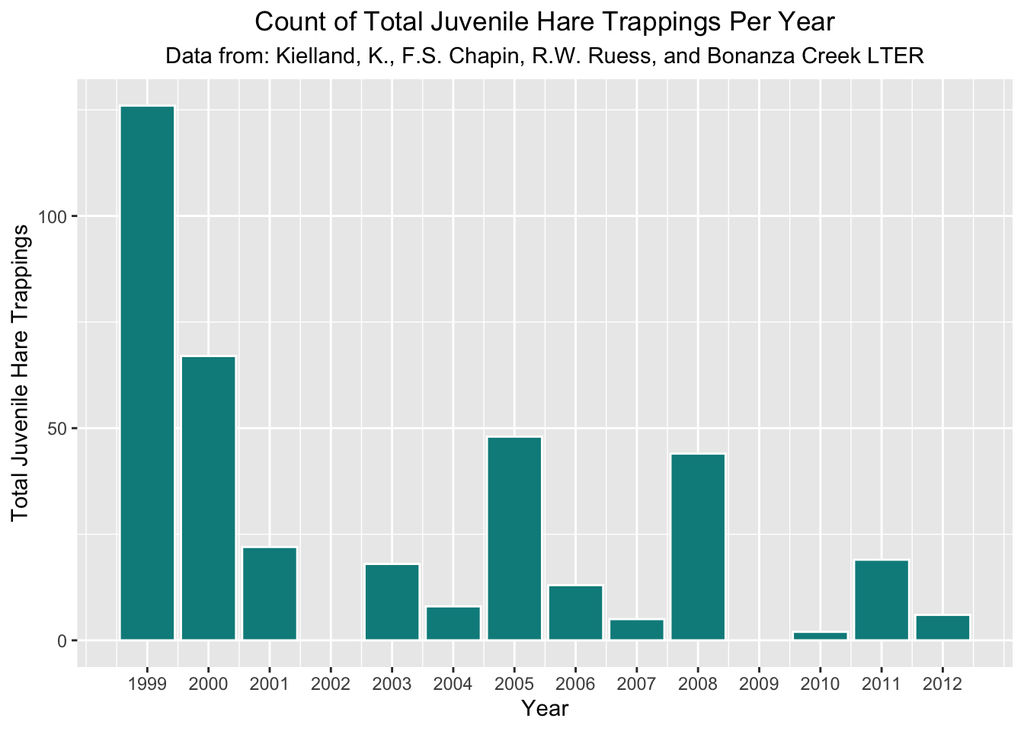

**Figure 2.** Count of total juvenile hare trappings from 1999 to 2012

**Analysis**: The minimum count of juvenile hare trapping (for those years where juvenile hares were actually trapped therefore values over 0), is 2, the maximum count of juvenile hare trapping is 126. The mean of juvenile hare trapping is 31.5, the median is 18.5. The standard deviation of the count of juvenile hare trapping is 35.9. In general there was a high number of juvenile hares trapped in 1999 and 2000, but there is a trend of decreasing hare trappings moving towards 2012, with spikes in 2005 and 2008. Moving forward in order to standardize the analysis of juvenile hare populations I would recommend ensuring that for each year that traps are put out for the study, they are left out the same number of days, checked at the same frequency, and placed in the same locations. By doing this, one can eliminate factors such as the habitat preferences of the hares and make sure that there is consistency across years.

**Table 1.** Descriptive statistics (mean, median, standard deviation, min, and max) for juvenile hare trap counts

| Count Mean | Count Median | Count Standard Deviation | Count Max | Count Min |
| --- | --- | --- | --- | --- |
| 31.5 | 18.5 | 35.9 | 126 | 2 |